# Waveforms

Diego

2023-05-19

# Modulación de Ancho de Pulso (PWM)

### PWM

La señal PWM (Pulse Width Modulation, Modulación de Ancho de Pulso) es una señal que utiliza el microcontrolador para generar una señal continua sobre el proceso a controlar.

### Ciclo de trabajo

El ciclo de trabajo, a veces denominado “factor de trabajo”, se expresa como un porcentaje del tiempo de activación. Por ejemplo, un ciclo de trabajo del 10% es una señal que se encuentra activada el 10% del tiempo y desactivada el otro 90%.

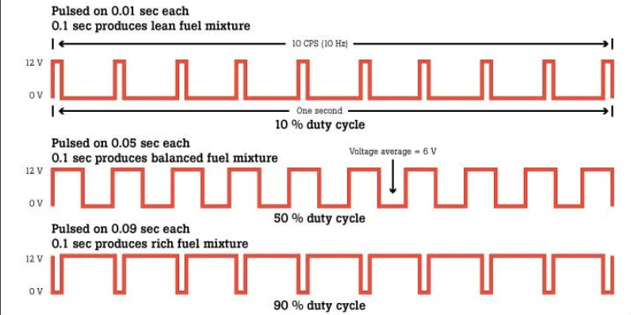

DutyCycle

### Simulacion en Multisim

```
Señales cuadradas solicitadas:
```

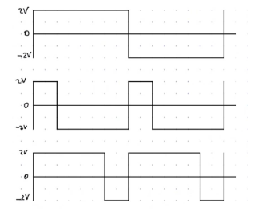

Señales Cuadradas

Para simular las señales cuadradas solicitadas deben seguirse los siguientes pasos:

1. Seleccionar el modo de onda cuadrada en el generador de funciones Agilent

[figure not shown]

SQ

1. Especificar la frecuencia a partir de la expresión

$$\omega = 5\pi
\frac{kRads}{s}$$

Siendo $\omega$ la frecuencia angular en kilo radianes y conociendo que

$$\omega = \frac{2 \pi}{T} \ \ y \ \ f =
\frac{1}{T}$$

por tanto

$$5\pi = \frac{2\pi}{T}$$

$$\frac{5\pi}{2\pi} =
\frac{1}{T}$$

$$\frac{5\cancel{\pi}}{2\cancel{\pi}} =
f$$

$$\boxed{Frecuencia \rarr 2.5kHz =
f}$$

[figure not shown]

2. Calcular el periodo de la señal

$$f = 2.5kHz = 2500Hz$$

$$T = \frac{1}{f}$$

$$T = \frac{1}{2500Hz}$$

$$\boxed{Periodo \rarr T = 0.0004s =
400\mu s}$$

3. Establecer el $V_{pp}$ en el generador

A partir de las figuras proporcionadas de las señales solicitadas, podemos identificar que la amplitud es de 2V o, lo que es lo mismo, un voltaje pico a pico de $V_{pp} = 4V$.

[figure not shown]

4. Ajustar las escalas de voltaje y tiempo en el osciloscopio

En este caso se emplearon divisiones de 2V para la escala del voltaje y, a su vez, se emplearon divisiones de 100$\mu$s para la escala del tiempo.

[figure not shown]

5. Ajustar el ciclo de trabajo

Para ajustar el ciclo de trabajo se debe presionar el botón `Shift` del generador de funciones y posteriormente el botón `Offset` , mismo que cuenta con leyenda de `% Duty`.

[figure not shown]